# R

Karthik

13 November 2015

# Introduction to R

## Types of objects:

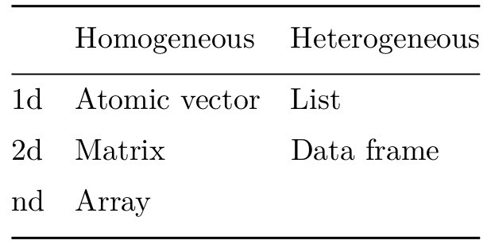

Use *str()* to see the structure of an object:

```r
x_vector = c(1,2,3,4)
str(x_vector)
```

```
##  num [1:4] 1 2 3 4
```

```r
x_list = list(foo = c(34,12,1), bar=c("foo", "bar"))
str(x_list)
```

```
## List of 2
##  $ foo: num [1:3] 34 12 1
##  $ bar: chr [1:2] "foo" "bar"
```

```r
x_matrix = matrix(x_vector, nrow = 2)
str(x_matrix)
```

```
##  num [1:2, 1:2] 1 2 3 4
```

```r
str(cars)
```

```
## 'data.frame':    50 obs. of  2 variables:
##  $ speed: num  4 4 7 7 8 9 10 10 10 11 ...
##  $ dist : num  2 10 4 22 16 10 18 26 34 17 ...
```

## Vectors

- Basic data type in R
- 2 flavours: Atomic vectors and lists
- 3 common properties: *typeof()*, *length()*, and *attributes()*

```r
typeof(x_vector)
```

```
## [1] "double"
```

```r
length(x_vector)
```

```
## [1] 4
```

```r
attributes(x_list)
```

```
## $names
## [1] "foo" "bar"
```

**Note:** Use *is.atomic() || is.list()* to check if an object is a vector. *is.vector* returns TRUE only if the object is a vector with no attributes apart from names.

```r
#this is wrong as we know x_list is a list!
is.vector(x_list) && is.vector(x_vector)
```

```
## [1] TRUE
```

```r
#this works!
is.atomic(x_list) || is.list(x_list)
```

```
## [1] TRUE
```

```r
#this as well
is.list(x_vector)
```

```
## [1] FALSE
```

#### Atomic vectors

Prefix *L* after the number to make it integer type:

```r
var = c(1,2,3)
#default type is double/numeric
typeof(var)
```

```
## [1] "double"
```

```r
int_var = c(1L,2L,3L)
typeof(int_var)
```

```
## [1] "integer"
```

#### Coersion

All elements of atomic vectors must be of same type. If not they will be coerced to tbe most flexible type (imlicit coersion). Types from least to most flexible are: logical, integer,double, and character.

```r
#character and integer gives a character
str(c(1,2,"a"))
```

```
##  chr [1:3] "1" "2" "a"
```

```r
#Logical and integer gives integer/double
str(c(1,2, TRUE))
```

```
##  num [1:3] 1 2 1
```

You can also explicity coerce the type of an object using *as.x()* functions.

```r
as.numeric(c(TRUE,FALSE, FALSE, TRUE))
```

```
## [1] 1 0 0 1
```

```r
as.logical(c(1,1,0,1))
```

```
## [1]  TRUE  TRUE FALSE  TRUE
```

```r
as.integer(c("a","b"))
```

```
## [1] NA NA
```

#### Lists

- Elements in a list can be of multiple type, includeing lists

```r
#create a list
x_list2 = list(Numbers=1:3, Logic=c(TRUE, TRUE, FALSE), Alphabets=letters[1:4])
#see the structure of a list
str(x_list2)
```

```
## List of 3
##  $ Numbers  : int [1:3] 1 2 3
##  $ Logic    : logi [1:3] TRUE TRUE FALSE
##  $ Alphabets: chr [1:4] "a" "b" "c" "d"
```

```r
#convert to vector
unlist(x_list2)
```

```
##   Numbers1   Numbers2   Numbers3     Logic1     Logic2     Logic3
##        "1"        "2"        "3"     "TRUE"     "TRUE"    "FALSE"
## Alphabets1 Alphabets2 Alphabets3 Alphabets4
##        "a"        "b"        "c"        "d"
```

```r
#convert a vector to list
str(as.list(x_vector))
```

```
## List of 4
##  $ : num 1
##  $ : num 2
##  $ : num 3
##  $ : num 4
```